# Explore and Summarize Data

Wenke Huang

August 11, 2017

# 0. Introduction

In this project, I would like to explore and summarize the dataset `Red Wine Quality`.

# 1. A stream-of-consciousness analysis and exploration

```
## 'data.frame':    1599 obs. of  12 variables:
##  $ fixed.acidity       : num  7.4 7.8 7.8 11.2 7.4 7.4 7.9 7.3 7.8 7.5 ...
##  $ volatile.acidity    : num  0.7 0.88 0.76 0.28 0.7 0.66 0.6 0.65 0.58 0.5 ...
##  $ citric.acid         : num  0 0 0.04 0.56 0 0 0.06 0 0.02 0.36 ...
##  $ residual.sugar      : num  1.9 2.6 2.3 1.9 1.9 1.8 1.6 1.2 2 6.1 ...
##  $ chlorides           : num  0.076 0.098 0.092 0.075 0.076 0.075 0.069 0.065 0.073 0.071 ...
##  $ free.sulfur.dioxide : num  11 25 15 17 11 13 15 15 9 17 ...
##  $ total.sulfur.dioxide: num  34 67 54 60 34 40 59 21 18 102 ...
##  $ density             : num  0.998 0.997 0.997 0.998 0.998 ...
##  $ pH                  : num  3.51 3.2 3.26 3.16 3.51 3.51 3.3 3.39 3.36 3.35 ...
##  $ sulphates           : num  0.56 0.68 0.65 0.58 0.56 0.56 0.46 0.47 0.57 0.8 ...
##  $ alcohol             : num  9.4 9.8 9.8 9.8 9.4 9.4 9.4 10 9.5 10.5 ...
##  $ quality             : int  5 5 5 6 5 5 5 7 7 5 ...
```

```
##  fixed.acidity   volatile.acidity  citric.acid    residual.sugar
##  Min.   : 4.60   Min.   :0.1200   Min.   :0.000   Min.   : 0.900
##  1st Qu.: 7.10   1st Qu.:0.3900   1st Qu.:0.090   1st Qu.: 1.900
##  Median : 7.90   Median :0.5200   Median :0.260   Median : 2.200
##  Mean   : 8.32   Mean   :0.5278   Mean   :0.271   Mean   : 2.539
##  3rd Qu.: 9.20   3rd Qu.:0.6400   3rd Qu.:0.420   3rd Qu.: 2.600
##  Max.   :15.90   Max.   :1.5800   Max.   :1.000   Max.   :15.500
##    chlorides       free.sulfur.dioxide total.sulfur.dioxide
##  Min.   :0.01200   Min.   : 1.00       Min.   :  6.00
##  1st Qu.:0.07000   1st Qu.: 7.00       1st Qu.: 22.00
##  Median :0.07900   Median :14.00       Median : 38.00
##  Mean   :0.08747   Mean   :15.87       Mean   : 46.47
##  3rd Qu.:0.09000   3rd Qu.:21.00       3rd Qu.: 62.00
##  Max.   :0.61100   Max.   :72.00       Max.   :289.00
##     density             pH          sulphates         alcohol
##  Min.   :0.9901   Min.   :2.740   Min.   :0.3300   Min.   : 8.40
##  1st Qu.:0.9956   1st Qu.:3.210   1st Qu.:0.5500   1st Qu.: 9.50
##  Median :0.9968   Median :3.310   Median :0.6200   Median :10.20
##  Mean   :0.9967   Mean   :3.311   Mean   :0.6581   Mean   :10.42
##  3rd Qu.:0.9978   3rd Qu.:3.400   3rd Qu.:0.7300   3rd Qu.:11.10
##  Max.   :1.0037   Max.   :4.010   Max.   :2.0000   Max.   :14.90
##     quality
##  Min.   :3.000
##  1st Qu.:5.000
##  Median :6.000
##  Mean   :5.636
##  3rd Qu.:6.000
##  Max.   :8.000
```

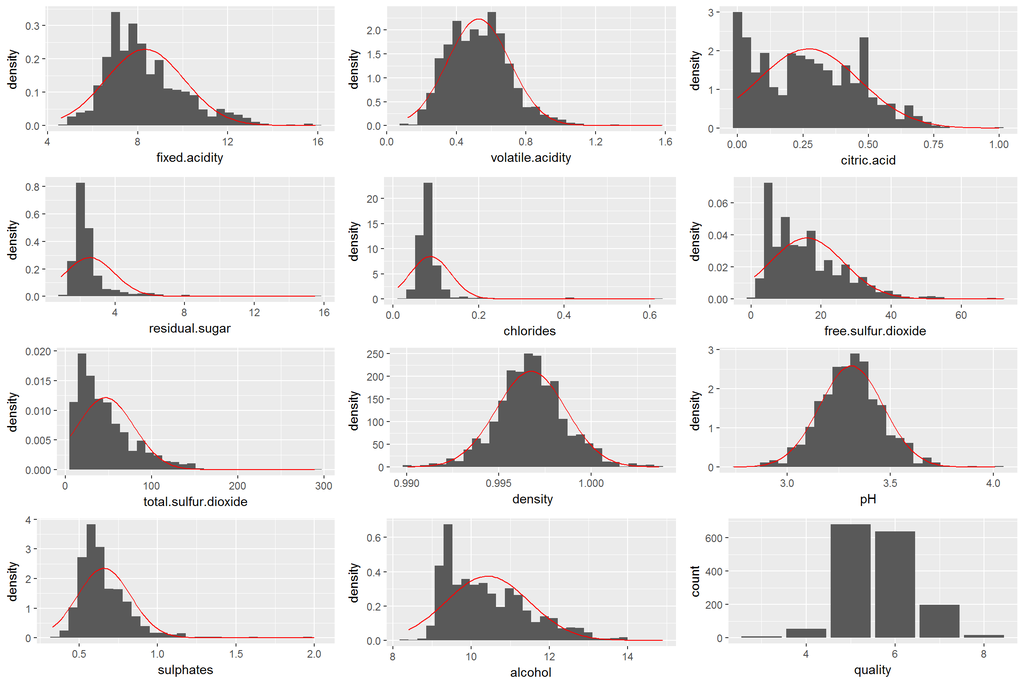

```
## [1] "We can find that many plots don't fit with the red normal distribution curve. We will perform logarithm transformation to see if they follow log-normal distribution apart from quality."
```

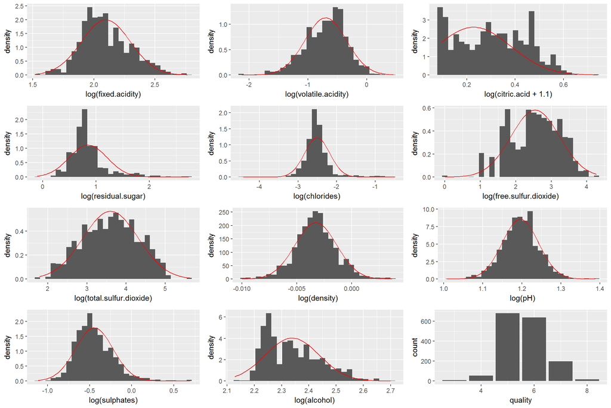

```
## [1] "We can find that many plots do fit with the new red normal distribution curve. The log-normal transformation can be considered later."
```

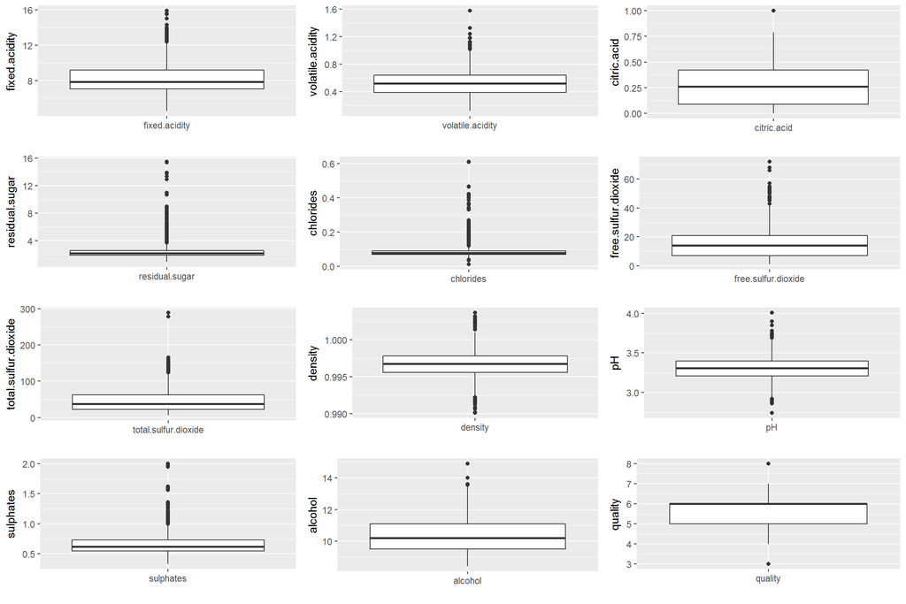

```
## [1] "In additiona to histograms, box plots can help us understand how our variables distribute, and at the same time detect the outliers."
```

```
##                      fixed.acidity volatile.acidity citric.acid
## fixed.acidity                1.000           -0.256       0.672
## volatile.acidity            -0.256            1.000      -0.552
## citric.acid                  0.672           -0.552       1.000
## residual.sugar               0.115            0.002       0.144
## chlorides                    0.094            0.061       0.204
## free.sulfur.dioxide         -0.154           -0.011      -0.061
## total.sulfur.dioxide        -0.113            0.076       0.036
## density                      0.668            0.022       0.365
## pH                          -0.683            0.235      -0.542
## sulphates                    0.183           -0.261       0.313
## alcohol                     -0.062           -0.202       0.110
##                      residual.sugar chlorides free.sulfur.dioxide
## fixed.acidity                 0.115     0.094              -0.154
## volatile.acidity              0.002     0.061              -0.011
## citric.acid                   0.144     0.204              -0.061
## residual.sugar                1.000     0.056               0.187
## chlorides                     0.056     1.000               0.006
## free.sulfur.dioxide           0.187     0.006               1.000
## total.sulfur.dioxide          0.203     0.047               0.668
## density                       0.355     0.201              -0.022
## pH                           -0.086    -0.265               0.070
## sulphates                     0.006     0.371               0.052
## alcohol                       0.042    -0.221              -0.069
##                      total.sulfur.dioxide density     pH sulphates alcohol
## fixed.acidity                      -0.113   0.668 -0.683     0.183  -0.062
## volatile.acidity                    0.076   0.022  0.235    -0.261  -0.202
## citric.acid                         0.036   0.365 -0.542     0.313   0.110
## residual.sugar                      0.203   0.355 -0.086     0.006   0.042
## chlorides                           0.047   0.201 -0.265     0.371  -0.221
## free.sulfur.dioxide                 0.668  -0.022  0.070     0.052  -0.069
## total.sulfur.dioxide                1.000   0.071 -0.066     0.043  -0.206
## density                             0.071   1.000 -0.342     0.149  -0.496
## pH                                 -0.066  -0.342  1.000    -0.197   0.206
## sulphates                           0.043   0.149 -0.197     1.000   0.094
## alcohol                            -0.206  -0.496  0.206     0.094   1.000
```

```
## [1] "The output above is the correlation coefficient matrix."
```

```
## [1] "citric.acid & fixed.acidity"
## [1] "total.sulfur.dioxide & free.sulfur.dioxide"
## [1] "density & fixed.acidity"
## [1] "pH & fixed.acidity"
```

```
## [1] "The pairs above indicate the variable pairs that has correlation coefficient not less than 0.6."
```

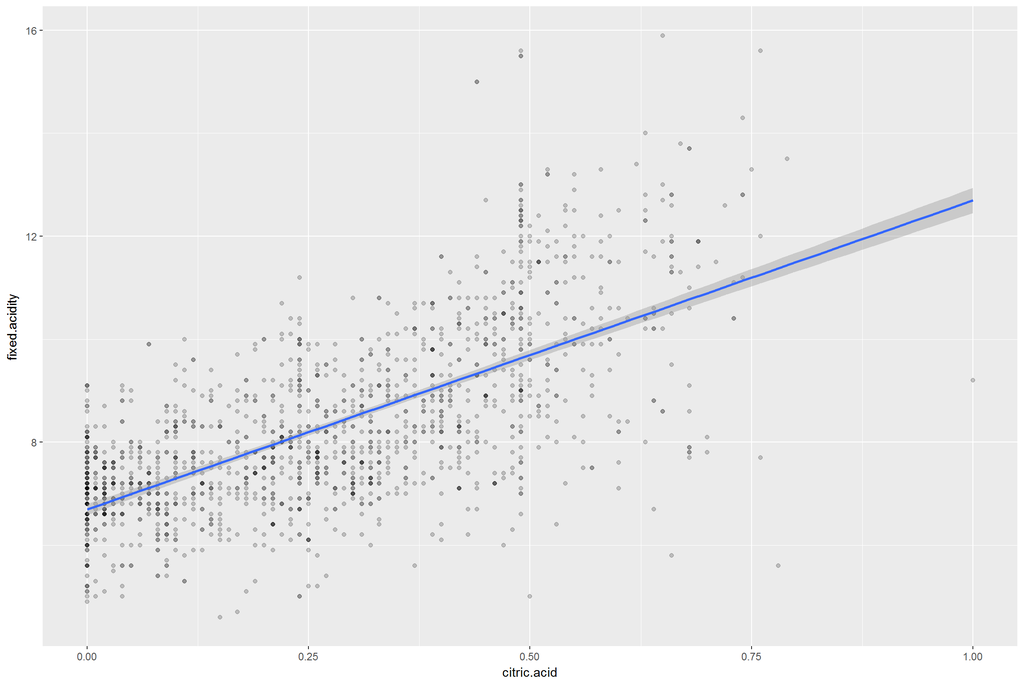

```
## [1] "The scatter plot of citric.acid and fixed.acidity plus their linear regression line indicates potential relationship between these two variables."
```

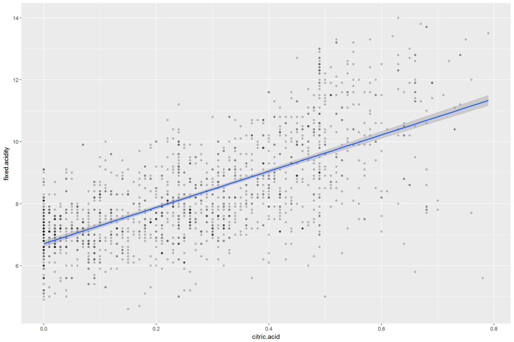

```
## [1] "We removed the outliers here. We can find that the linear regression line moved slightly."
```

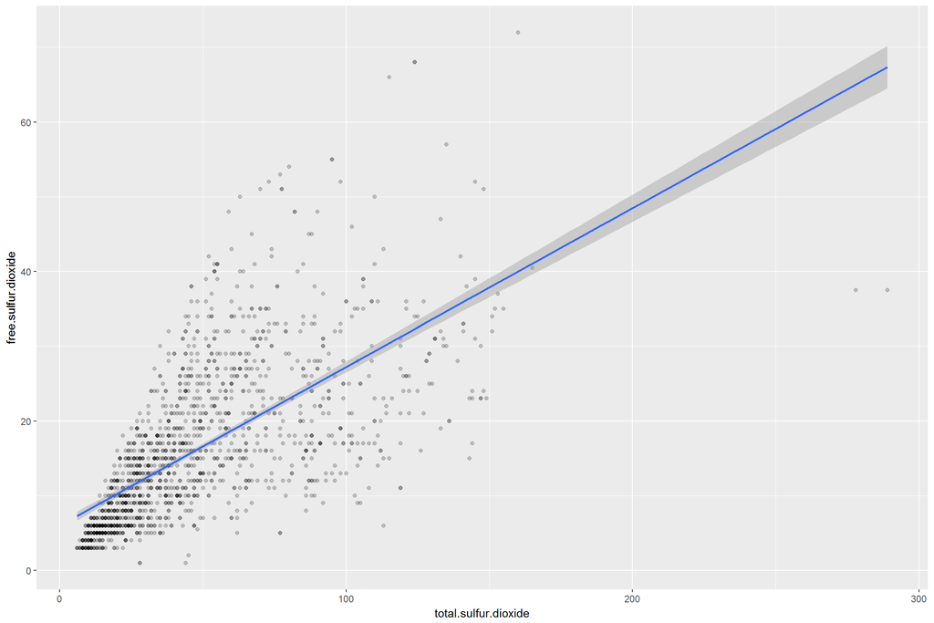

```
## [1] "The scatter plot of total.sulfur.dioxide and free.sulfur.dioxide plus their linear regression line indicates potential relationship between these two variables."
```

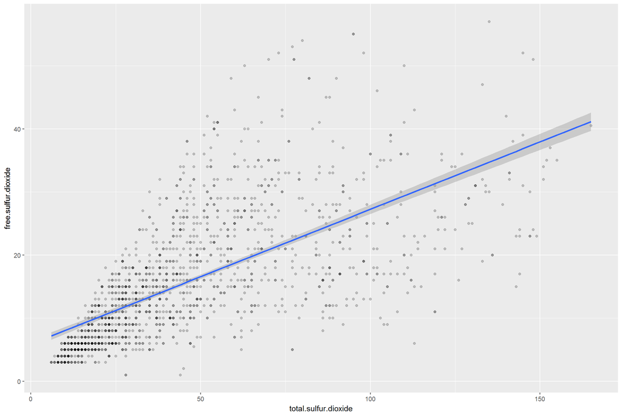

```
## [1] "We removed the outliers here. We can find that the linear regression line moved slightly."
```

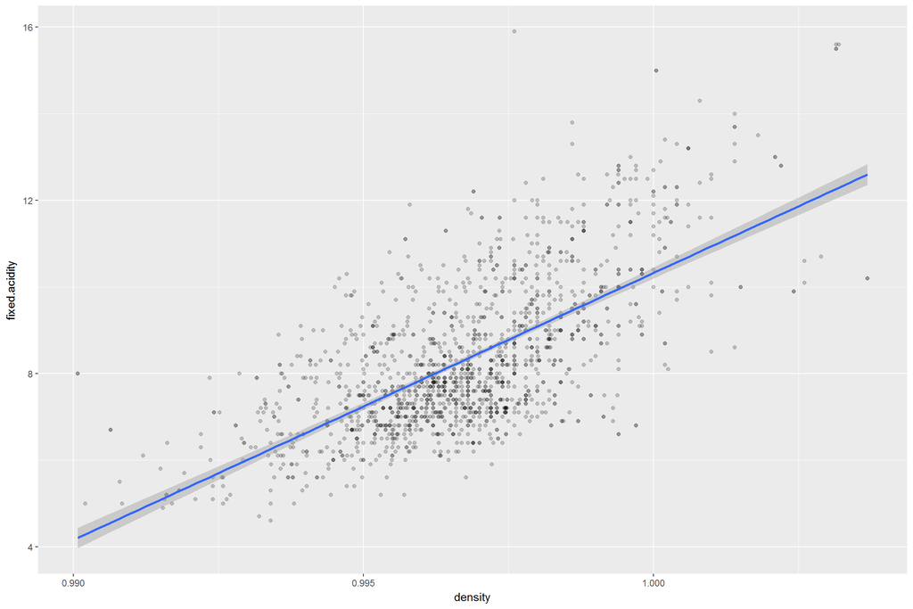

```
## [1] "The scatter plot of density and fixed.acidity plus their linear regression line indicates potential relationship between these two variables."
```

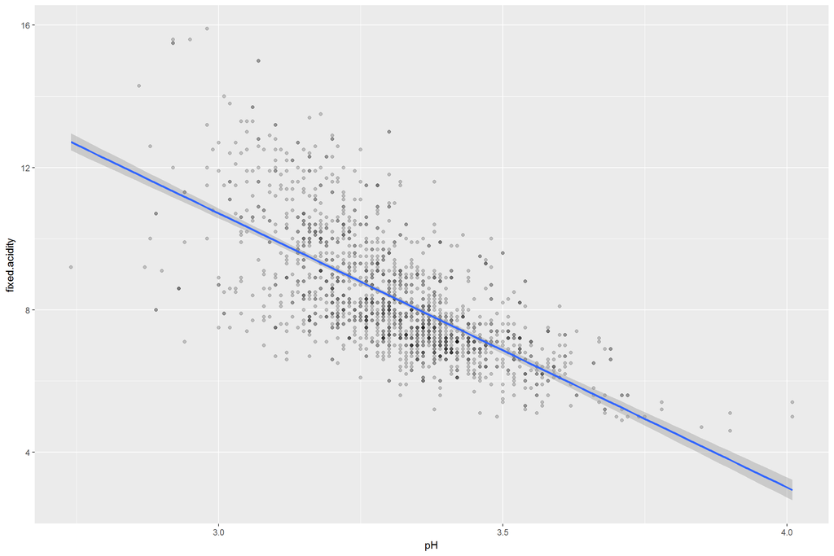

```
## [1] "The scatter plot of pH and fixed.acidity plus their linear regression line indicates potential relationship between these two variables."
```

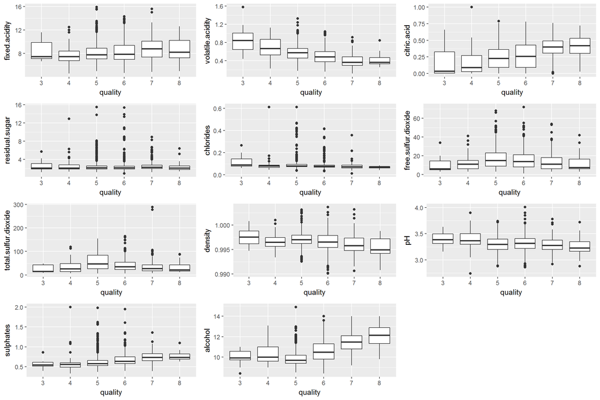

```
## [1] "Boxplot shows us that among different qualities, the corresponding variables tend to have different values."
```

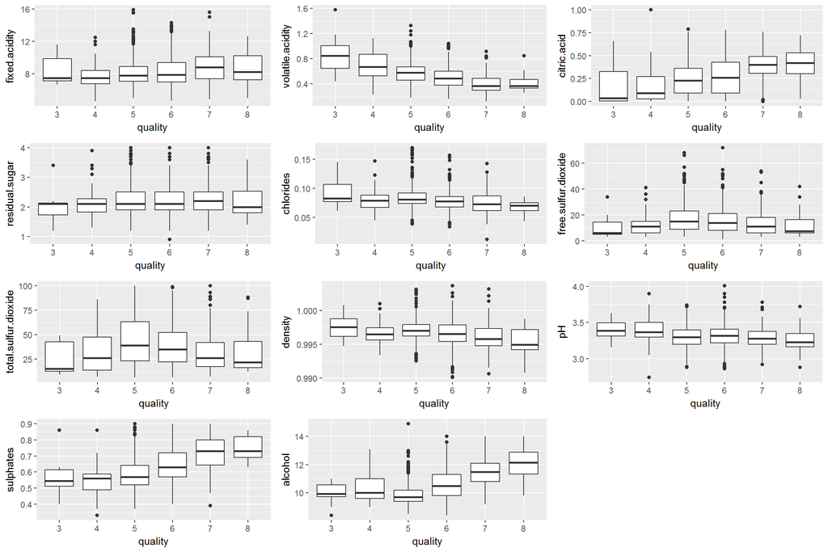

```
## [1] "It's hard to detect some useful info because of outliers. After removing them, we are able to have a better and clearer understanding of these box plots."
```

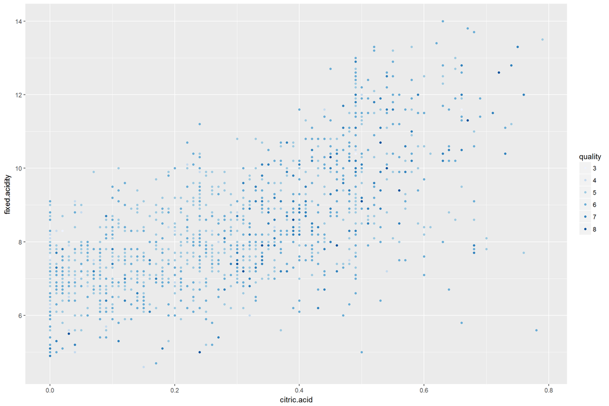

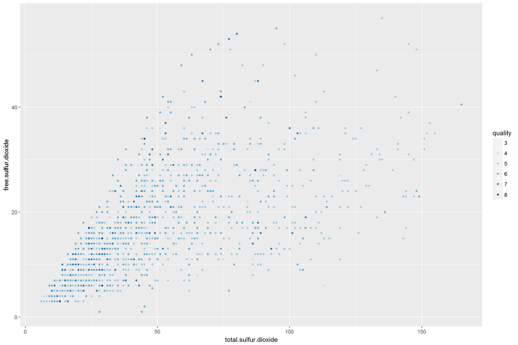

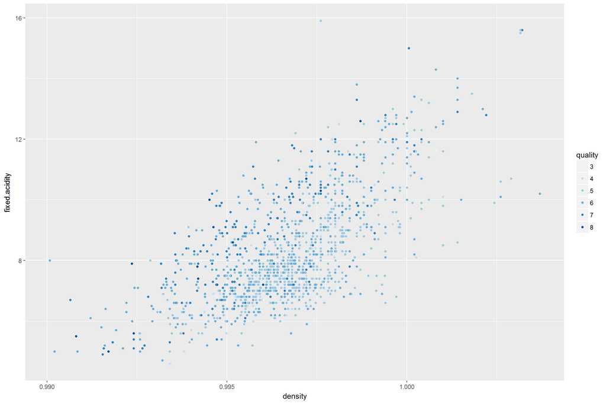

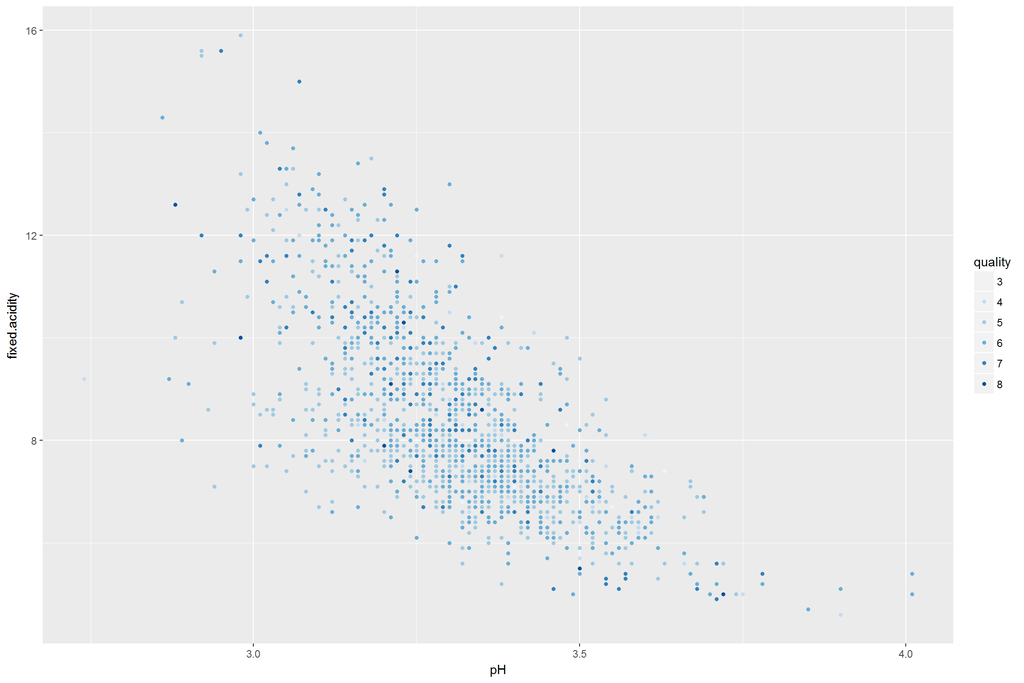

```
## [1] "In this plot and the following three, we colored the plots based on different qualities. The darker color indicates higher quality while lighter color indicates lower quality."
```

```
## [1] "It's hard to detect any trend that is related with quality and this two axes. Here, we would like do dig deeper. We set 'bad' quality if score is not greater than 5 and 'good' quality if it is greater than 5."
```

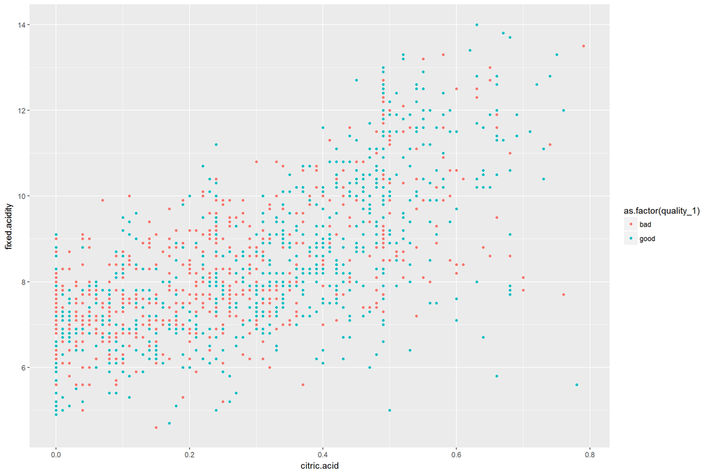

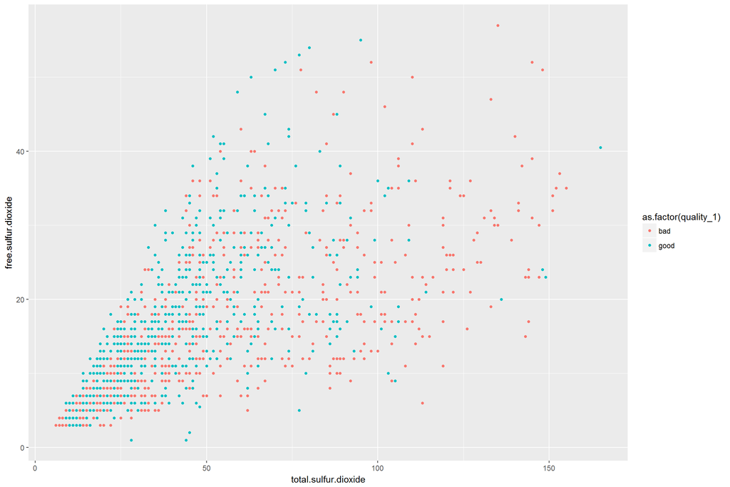

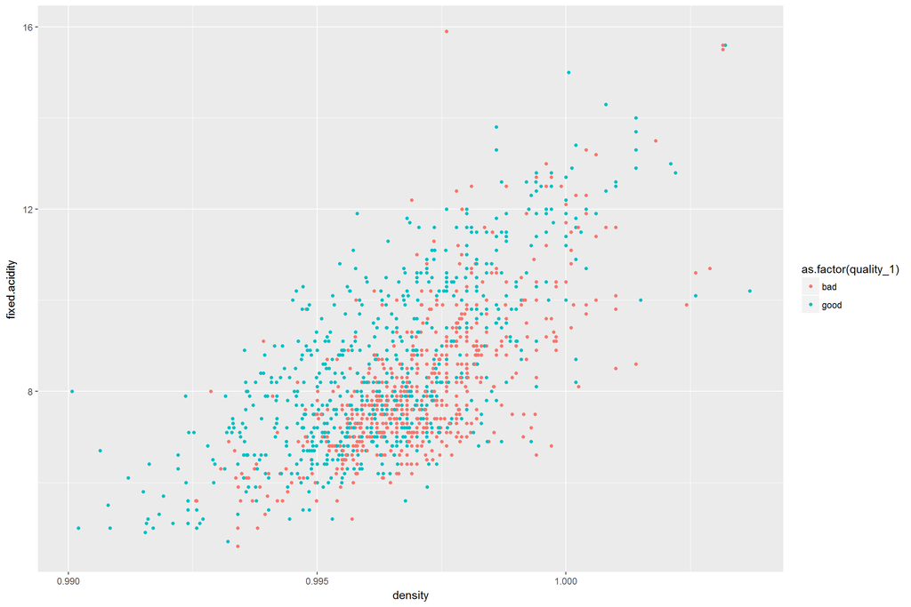

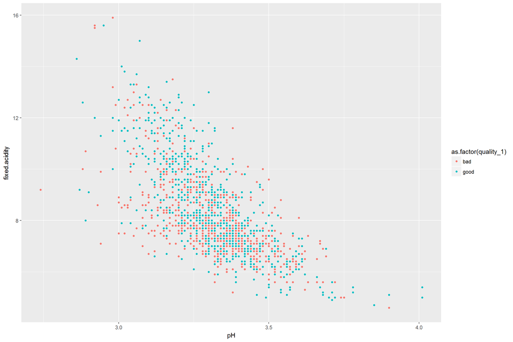

```
## [1] "The plot fixed.acidity vs density seems to have something interesting. Because bad quality wine tends to have lower fixed.density than good quality wine. For the rest three plots, it's still hard to grab something useful."
```

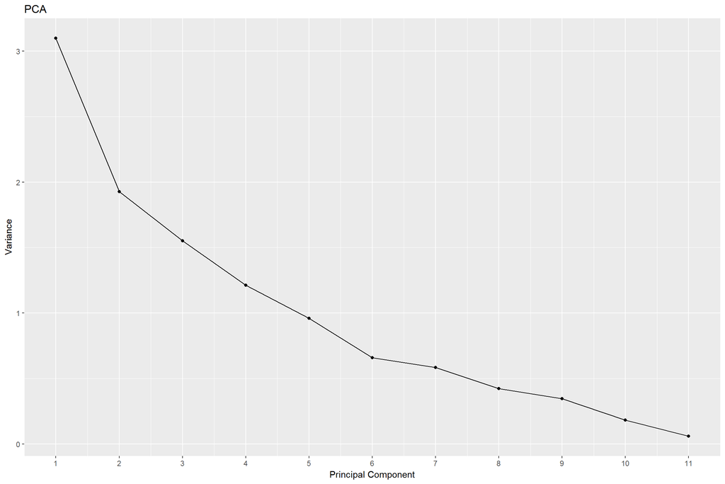

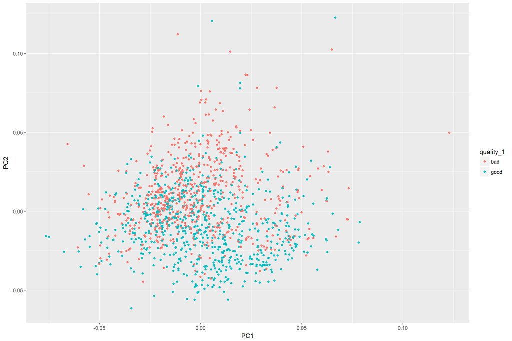

[output not shown]

# 2. Final Plots and Summary

## 2.1 Histogram of total.sulfur.dioxide

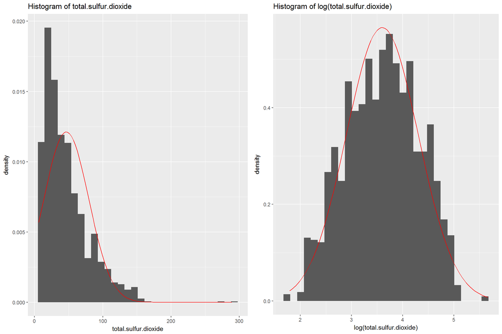

The plot on the left is the histogram of our variable `total.sulfur.dioxide` while the plot on the right is the histogram of the same variable `total.sulfur.dioxide` after logarithm transformation. The red lines in both histograms represent the normal distribution curves with mean and standard deviation being equal to sample mean and standard deviation, respectively.

It is obvious that the variable `total.sulfur.dioxide` does not follow normal distribution based on the left histogram. Because its positively skewed distribution does not fit with the normal distribution curve.

Furtherly, we would like to test if it follows log-normal distribution. The plot on the right shows us that the histogram of `log(total.sulfur.dioxide)` with its normal distribution curve. This one looks much more “normal” than the left one since there is no obvious positive or negative skewness and its distribution basically fits its corresponding normal distribution curve.

Hence, we can conclude that the variable `total.sulfur.dioxide` basically follows the log-normal distribution.

## 2.2 Scatter plot of free.sulfur.dioxide vs total.sulfur.dioxide

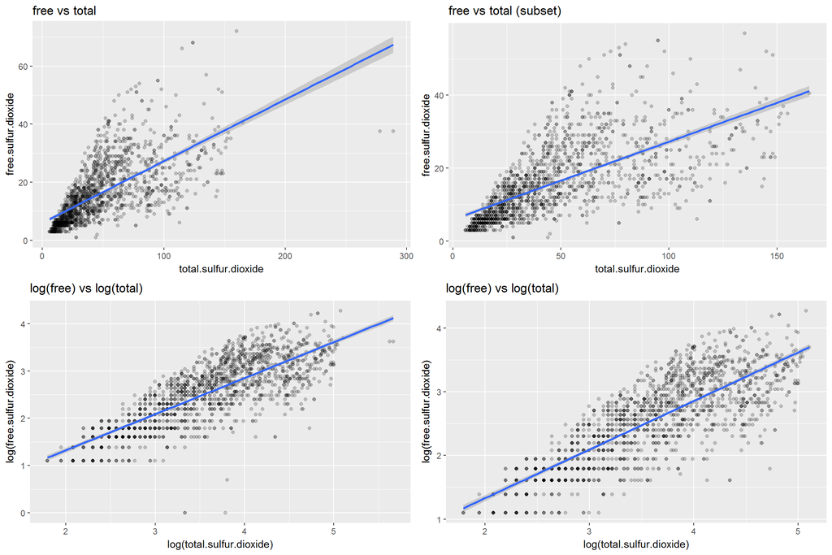

The four plots here are scatter plots related with variable `free.sulfur.dioxide` vs `total.sulfur.dioxide`. The word `free` and `total` represent `free.sulfur.dioxide` and `total.sulfur.dioxide`, respectively. `log()` means that we perform logarithm transformation on the corresponding variable. The blue line in the plot shows the linear regression line.

The bottom-left plot shows that the linear trend is much more obvious after we perform logarithm transformation on both variables. The bottom-right plot is the scatter plot after we remove outliers. The outliers here may not be exactly the same as the top-right plot. We can notice that these two regression lines were basically at the same position.

Hence, we may think that `total.sulfur.dioxide` and `free.sulfur.dioxide` are highly correlated with each other. Especially after we perform logarithm transformation on both variables, there exists an obvious linear trend. Additionally, the pearson correlation coefficient of these two variables and these two after logarithm transformation are 0.6676665 and 0.7846217, respectively, which also prove our opinion.

## 2.3 Principal Component Analysis plot

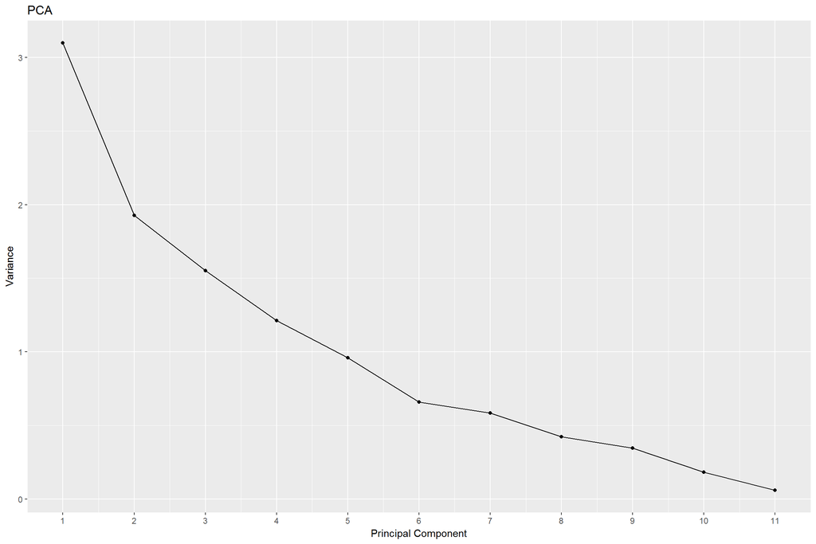

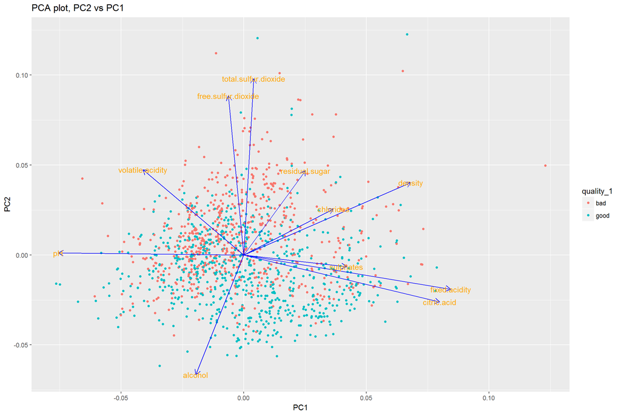

Here, we drew our scatter plot of PC2 vs PC1. It is still not very clear to clearly define the ‘territory’ of different qualities, Especially, when PC2 is positive. However, when we have a negative PC2, it tends to be much clearer that most points of this area are pre-defined as a good quality wine.

Based on the plot of PCA we can see that, the first two Principal Components do not explain most of the variances, and additional principal components should be added in case we may face the issue of under-fitting. This may also be the reason that the scatter plot of PC2 vs PC1 may not give us the exact result that we want.

# 3. Reflection

## 3.1 My struggle

When I tried to find if we can cluster or stratify the scatter plots obtained from part 2.2 by using variable `quality`, I found its impossible to do that. Because I cannot find any obvious trend which may lead me to the result that I would like to have.

## 3.2 My success

Most plots have good performances. For example, I successfully found out the distributions of different variables and compared them with the corresponding normal distribution curve. Since some of the distributions look like a log-normal distribution, I also performed logarithm transformation and successfully found several variables which may follow log-normal distribution, such as `total.sulfur.dioxide`.

## 3.3 Future work

In the future, I would like to mainly focus on the struggle that I had.

- Very few wine products have the score lower than 5 or greater than 7. I may try use the subset of wine products with quality score being 5, 6 and 7 only and reperform PCA.
- After we finished detecting outliers, we may think removing those points which may influence our model seriously. Without outliers, we may be able to get the results that we want.
- We already detected that some variables follow log-normal distribution. We can firstly tranform those variables, then reperform PCA based on our new dataset.

# Reference

N/A